# My R Codes For Data Analysis

In this repository I am going to collect `R codes` for data analysis. Codes are from various resources and I try to give original link as much as possible.

[Serdar Balcı, MD, Pathologist](https://www.serdarbalci.com/)

2019-03-24

# 1 Prepare Data for Analysis / Veriyi Analiz için hazırlamak

## 1.1 The Quartz guide to bad data

> An exhaustive reference to problems seen in real-world data along with suggestions on how to resolve them.

https://github.com/Quartz/bad-data-guide

## 1.2 Kötü veri kılavuzu

Kötü veri kılavuzu

https://sbalci.github.io/Kotu-Veri-Kilavuzu/index.html

## 1.3 data organization organizing data in spreadsheets

https://kbroman.org/dataorg/

Daniel Kaplan. (2018) Teaching Stats for Data Science. The American Statistician 72:1, pages 89-96.

https://doi.org/10.1080/00031305.2017.1375989

## 1.4 Tidy Data

Hadley Wickham. Tidy data. The Journal of Statistical Software, vol. 59, 2014.

http://vita.had.co.nz/papers/tidy-data.html https://www.jstatsoft.org/article/view/v059i10 http://dx.doi.org/10.18637/jss.v059.i10

## 1.5 The Ten Commandments for a well-formatted database

- The Ten Commandments for a well-formatted database

https://rtask.thinkr.fr/blog/the-ten-commandments-for-a-well-formatted-database/

## 1.6 Software specific problems

### 1.6.1 Keep SPSS labels

```r
library(foreign) # foreign paketi yükleniyor
```

read.spss komutu ile değer etiketlerini almasını ve bunu liste olarak değil de data.frame olarak kaydetmesini istiyoruz

```r
mydata <- read.spss("mydata.sav", use.value.labels = TRUE, to.data.frame = TRUE)
```

aktardığımız data.frame’in özellikleri (attr) içinde değişkenlerin etiketleri var, bunları dışarı çıkartıyoruz

```r
VariableLabels <- as.data.frame(attr(mydata, "variable.labels"))
```

elde ettiğimiz data.frame’deki satır isimleri değişkenlerin isimleri oluyor, karşılarında da değişken etiketleri var satır isimlerini de dışarı çıkartıyoruz

```r
VariableLabels$original <- rownames(VariableLabels)
```

Değişken etiketi olanları etiketleri ile diğerlerini olduğu gibi saklıyoruz

```r
VariableLabels$label[VariableLabels$label ==""] <- NA
VariableLabels$colname <- VariableLabels$original
VariableLabels$colname[!is.na(VariableLabels$label)] <- as.vector(VariableLabels$label[!is.na(VariableLabels$label)])
```

son olarak da data.frame’deki sütun isimlerini değiştiriyoruz

```r
names(mydata) <- VariableLabels$colname
```

### 1.6.2 Make both computer and human readible variable names

turkce karakter donusumu

```r
# https://suatatan.wordpress.com/2017/10/07/bulk-replacing-turkish-characters-in-r/

to.plain <- function(s) {
        # 1 character substitutions
    old1 <- "çğşıüöÇĞŞİÖÜ"
    new1 <- "cgsiuocgsiou"
    s1 <- chartr(old1, new1, s)
    # 2 character substitutions
    old2 <- c("œ", "ß", "æ", "ø")
    new2 <- c("oe", "ss", "ae", "oe")
    s2 <- s1
    for(i in seq_along(old2)) s2 <- gsub(old2[i], new2[i], s2, fixed = TRUE)
    s2
}

names(df) <- make.names(to.plain(tolower(names(df))))

names(df) <- names(df) %>%
    tolower() %>%
    to.plain() %>%
    make.names()

df$source=as.vector(sapply(df$source,to.plain))

make.names(tolower(names(df)))
to.plain(names(df))

purrr::map(df, to.plain)
```

### 1.6.3 Anonimisation

### 1.6.4 Add subject ID to the data / veriye ID ekleme

```r
df <- tibble::rowid_to_column(df, "subject")
```

## 1.7 Data reorganization

```r
scabies <- read.csv(file = "http://datacompass.lshtm.ac.uk/607/2/S1-Dataset_CSV.csv", header = TRUE, sep = ",")

scabies$gender == "male"

scabies$age[scabies$gender == "male"]

mean(scabies$age[scabies$gender == "male"])


scabies %>%
    filter(gender == "male") %>%
    summarise_at("age" ,mean)
```

```r
scabies$agegroups <- as.factor(cut(scabies$age, c(0,10,20,Inf), labels = c("0-10","11-20","21+"), include.lowest = TRUE))

scabies$house_cat <- as.factor(cut(scabies$house_inhabitants, c(0,5,10,Inf), labels = c("0-5","6-10","10+"), include.lowest = TRUE))


table(scabies$house_cat, scabies$house_inhabitants)
```

```r
ebola$status <- as.numeric(ebola$status)
```

```r
ebola$transmission <- recode(ebola$transmission, syringe = "needle")
```

```r
scabies$house_cat <- relevel(scabies$house_cat, ref = "0-5")
#Make 0-5 household size the baseline group
```

```r
df <- data.frame(month=rep(1:3,2),
                 student=rep(c("Amy", "Bob"), each=3),
                 A=c(9, 7, 6, 8, 6, 9),
                 B=c(6, 7, 8, 5, 6, 7))
#Here we have a where each student is on a different row for each month
#The students took two tests A and B.
#For each student/month combination we have a value for A and a value for B

df2 <- gather(df,test,score,A:B)
#Make a new datatable df2
#Have a column called "test".
#This will have the value either A or B as these are the names of the columns we specified.
#Have a column called "score".
#This will have the value previously in column A or B respectively for each row

df2
```

```r
#Now we have a single row for each combination of month/student/test
#Their score is in the score column

df3 <- spread(df2,test,score)
#Make a new datatable df3
#Make a column for each unique value in the test variable.
#Name each of these columns based on that unique value
#Under each column put the corresponding value that was in the score column

df3
```

```r
dt3 <- expandRows(dt, 2)
#Expand the original datatable. Replicate each row by the value in column 2.
dt3
```

https://stackoverflow.com/questions/22353633/filter-for-complete-cases-in-data-frame-using-dplyr-case-wise-deletion

df %>% na.omit or this:

df %>% filter(complete.cases(.)) or this:

library(tidyr) df %>% drop_na If you want to filter based on one variable’s missingness, use a conditional:

df %>% filter(!is.na(x1)) or

df %>% drop_na(x1) Other answers indicate that of the solutions above na.omit is much slower but that has to be balanced against the fact that it returns and row indices of the omitted rows as the na.action attribute whereas the other solutions above do not.

str(df %>% na.omit) ‘data.frame’: 2 obs. of 2 variables: $ x1: num 1 2 $ x2: num 1 2 - attr(*, “na.action”)= ‘omit’ Named int 3 4 ..- attr(*, “names”)= chr “3” “4”

ozp <- veri %>% select(RaporNo, Hasta, cinsiyet, Yas, ozp_parca, ozp_kaset, ozp_cap, ozp_tani, ozp_kod) %>% filter(!is.na(ozp_parca) | !is.na(ozp_kaset) | !is.na(ozp_cap) | !is.na(ozp_tani) | !is.na(ozp_kod) )

ozp2 <- veri %>% select(RaporNo, Hasta, cinsiyet, Yas, ozp_parca, ozp_kaset, ozp_cap, ozp_tani, ozp_kod) %>% filter(complete.cases(ozp_parca, ozp_kaset, ozp_cap, ozp_tani, ozp_kod) )

ozp3 <- veri %>% select(RaporNo, Hasta, cinsiyet, Yas, ozp_parca, ozp_kaset, ozp_cap, ozp_tani, ozp_kod) %>% na.omit(ozp_parca, ozp_kaset, ozp_cap, ozp_tani, ozp_kod)

# 2 xray

The R Package to Have X Ray Vision on your Datasets

https://blog.datascienceheroes.com/x-ray-vision-on-your-datasets/

```r
# install.packages("devtools")
devtools::install_github("sicarul/xray")
```

```r
xray::anomalies(badLongley)
```

```
Found 1 possible problematic variables:
GNP
```

| Variable | q | qNA | pNA | qZero | pZero | qBlank | pBlank | qInf | pInf | qDistinct | type | anomalous_percent |
| --- | --- | --- | --- | --- | --- | --- | --- | --- | --- | --- | --- | --- |
| GNP | 16 | 16 | 100% | 0 | - | 0 | - | 0 | - | 1 | Logical | 100% |
| GNP.deflator | 16 | 0 | - | 0 | - | 0 | - | 0 | - | 16 | Numeric | - |
| Unemployed | 16 | 0 | - | 0 | - | 0 | - | 0 | - | 16 | Numeric | - |
| Armed.Forces | 16 | 0 | - | 0 | - | 0 | - | 0 | - | 16 | Numeric | - |
| Population | 16 | 0 | - | 0 | - | 0 | - | 0 | - | 16 | Numeric | - |
| Year | 16 | 0 | - | 0 | - | 0 | - | 0 | - | 16 | Integer | - |
| Employed | 16 | 0 | - | 0 | - | 0 | - | 0 | - | 16 | Numeric | - |

| Variable | q | qNA | pNA | qZero | pZero | qBlank | pBlank | qInf | pInf | qDistinct | type | anomalous_percent | problems |
| --- | --- | --- | --- | --- | --- | --- | --- | --- | --- | --- | --- | --- | --- |
| GNP | 16 | 16 | 100% | 0 | - | 0 | - | 0 | - | 1 | Logical | 100% | Anomalies present in 100% of the rows. Less than 2 distinct values. |

```
NA
```

| Variable | p_1 | p_10 | p_25 | p_50 | p_75 | p_90 | p_99 |
| --- | --- | --- | --- | --- | --- | --- | --- |
| GNP.deflator | 83.78 | 88.35 | 94.525 | 100.6 | 111.25 | 114.95 | 116.72 |
| GNP | 237.8537 | 258.74 | 317.881 | 381.427 | 454.0855 | 510.387 | 549.3859 |
| Unemployed | 187.93 | 201.55 | 234.825 | 314.35 | 384.25 | 434.4 | 478.725 |
| Armed.Forces | 147.61 | 160.3 | 229.8 | 271.75 | 306.075 | 344.85 | 358.695 |
| Population | 107.7616 | 109.2025 | 111.7885 | 116.8035 | 122.304 | 126.61 | 129.7466 |
| Year | 1947.15 | 1948.5 | 1950.75 | 1954.5 | 1958.25 | 1960.5 | 1961.85 |
| Employed | 60.1938 | 60.7225 | 62.7125 | 65.504 | 68.2905 | 69.4475 | 70.403 |

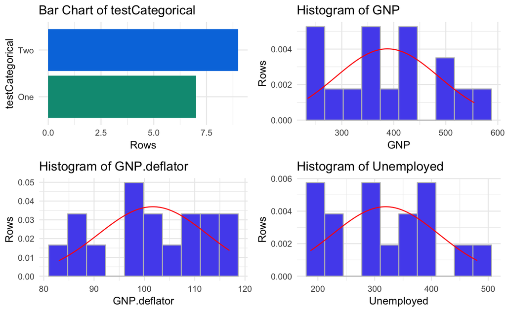

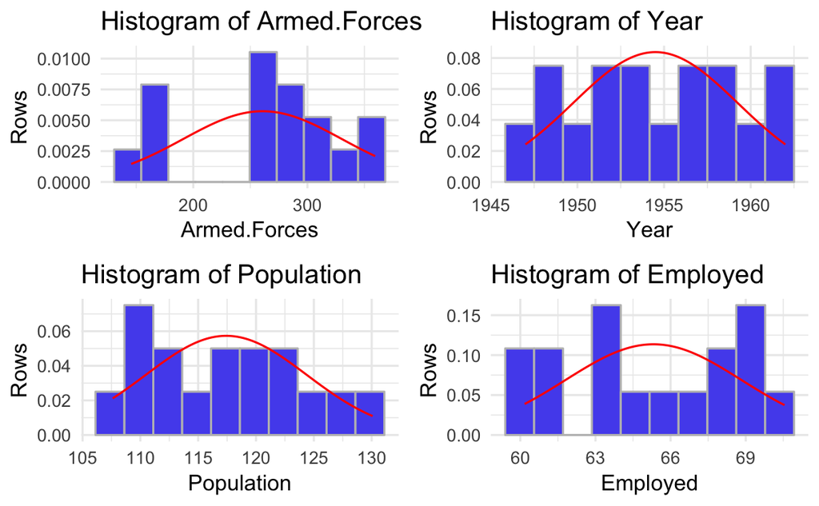

```r
xray::distributions(distrLongley)
```

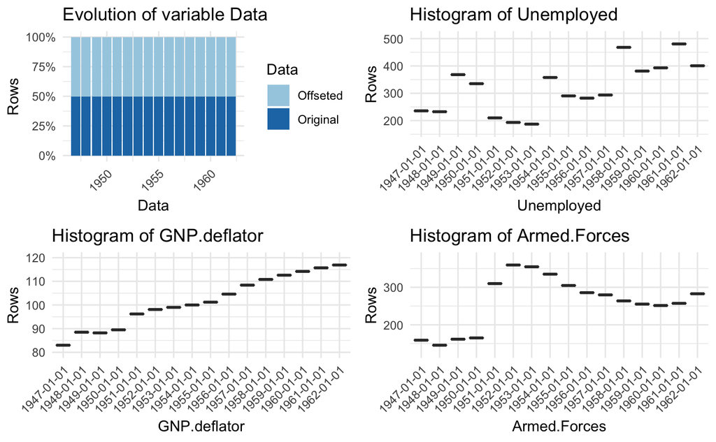

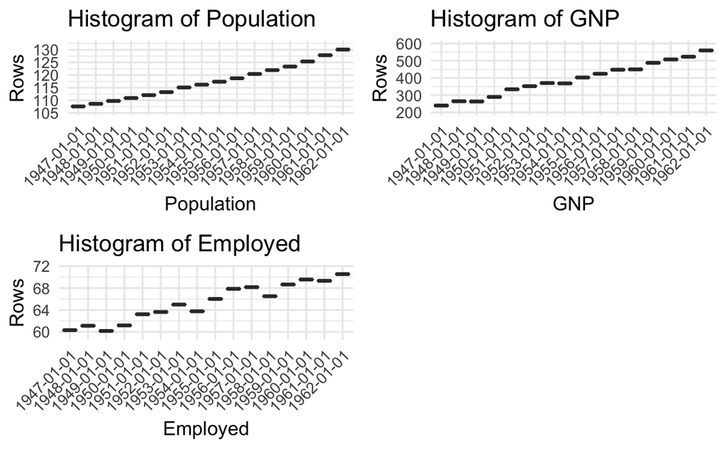

```r
xray::timebased(rbind(dateLongley, ndateLongley), 'Year')
```

# 3 convert all data.frame into character

df <- purrr::map_df(df, as.character)

# 4 R:case4base - reshape data with base R

https://jozefhajnala.gitlab.io/r/r002-data-manipulation/

# 5 R:case4base - data aggregation with base R

https://jozefhajnala.gitlab.io/r/r003-aggregation/

# 6 tidyr

> This week I'm going to be looking at some [#tidyr](https://twitter.com/hashtag/tidyr?src=hash&ref_src=twsrc%5Etfw) functions! 💡 First is uncount() which might come in handy if you want to transform a summary table to individual rows. [#rstats](https://twitter.com/hashtag/rstats?src=hash&ref_src=twsrc%5Etfw) [pic.twitter.com/UZE0wUcEHC](https://t.co/UZE0wUcEHC)

> — Nic Crane (@nic_crane) [November 26, 2018](https://twitter.com/nic_crane/status/1066964776276893696?ref_src=twsrc%5Etfw)

```
df <- data.frame(
          V1 = c(0, 0, 0, 0, 1, 1, 1, 1, 0, 1),
          V2 = c(1, 1, 1, 0, 0, 0, 0, 0, 0, 1),
          V3 = c(0, 0, 0, 1, 1, 1, 1, 1, 0, 1)
)


df$V1_rec <- grepl(pattern = "0", x = df$V1)
df$V2_rec <- grepl(pattern = "0", x = df$V2)
df$V3_rec <- grepl(pattern = "0", x = df$V3)

df %>%
    mutate(toplam = select(., V1_rec:V3_rec) %>% rowSums(na.rm = TRUE)
               )
```